# FIT3181 S2 2023 - ASSIGNMENT 1

Due: [11:59pm, 08 September 2023] (Friday)

**Important note:** This is an **individual** assignment. It contributes **25%** to your final mark. Read the assignment instruction carefully.

# Student Information

Surname: **[Sun]**  
Firstname: **[Xiaoyu ]**  
Student ID: **[32950683 ]**  
Email: **[xsun0054@student.monash.edu ]**  
Your tutorial time: **[Fri 2-4pm ]**

## Instruction

This notebook has been prepared for your to complete Assignment 1. The theme of this assignment is about practical machine learning knowledge and skills in deep neural networks, including feedforward and convolutional neural networks. Some sections have been partially completed to help you get started. **The total marks for this notebook is 100**.

- Before you start, read the entire notebook carefully once to understand what you need to do.
- For each cell marked with **#YOU ARE REQUIRED TO INSERT YOUR CODES IN THIS CELL** or **INSERT YOUR CODES IN THIS CELL**, there will be places where you **must** supply your own codes when instructed.

This assignment contains **three** parts:

- Part 1: Questions on theory and knowledge on machine learning and deep learning **[30 points]**
- Part 2: Coding assessment on TensorFlow for Deep Neural Networks (DNN) **[30 points]**
- Part 3: Coding assessment on TensorFlow for Convolution Neural Networks (CNN) **[40 points]**

**Hint**: This assignment was essentially designed based on the lectures and tutorials sessions covered from Week 1 to Week 5. You are strongly recommended to go through these contents thoroughly which might help you to complete this assignment.

## What to submit

This assignment is to be completed individually and submitted to Moodle unit site. **By the due date, you are required to submit one single zip file, named xxx_assignment01_solution.zip where `xxx` is your student ID, to the corresponding Assignment (Dropbox) in Moodle**.

*For example, if your student ID is 12356, then gather all of your assignment solution to folder, create a zip file named 123456_assignment01_solution.zip and submit this file.*

Within this zip folder, you **must** submit the following files:

1. **A1_Part1_Solutions.ipynb, A1_Part2_Solutions.ipynb, A1_Part3_Solutions.ipynb**: these are your Python notebook solution source files.
2. **A1_Part1_Solutions.html, A1_Part2_Solutions.html, A1_Part3_Solutions.html**: these are the output of your Python notebook solution *exported* in HTML format.
3. Any **extra files or folder** needed to complete your assignment (e.g., images used in your answers).

**You can run your codes on Google Colab. In this case, you need to capture the screenshots of your Google Colab model training and put in corresponding places in your Jupyter notebooks. You also need to store your trained models to folder *./models* with recognizable file names (e.g., Part3_Sec3_2_model.h5).**

## Part 1: Theory and Knowledge Questions

[Total marks for this part: 30 points]

The first part of this assignment is for you to demonstrate your knowledge in deep learning that you have acquired from the lectures and tutorials materials. Most of the contents in this assignment are drawn from **the lectures and labs from weeks 1 to 2**. Going through these materials before attempting this part is highly recommended.

**Numpy** is possibly being used in the following questions. You need to import it here.

```python
import numpy as np
```

### Question 1.1: Activation Functions

Activation function plays an important role in modern Deep NNs. In this question, we will explore some of them to get deeper understanding of their characteristics and their advantages.

**(a)** Given the Exponential Linear Unit activation function: $$\text{ELU}\left(x\right)=\begin{cases}\alpha\,(e^x-1) & \text{if}\,x<0\ (\alpha\ \text{is a hyper-parameter})\\x & \text{otherwise}\end{cases}$$

State its output range, find its derivative (show your steps), and plot the activation fuction and its derivative.

[2 points]

**(b)** In literature, there are a wide range of activation functions that have been proposed. Do a research and select two (2) activation functions that were not discussed in the lecture (including `ReLU`, `sigmoid`, and `tanh`). For each of the selected activation function, do the following:

- Find the research paper which propose the activation function.
- Write a brief summary of the author's motivation which leads to the activation function (max 150 words).
- Write a brief summary of advantages of the activation function (max 150 words).

[6 points]

*# WRITE YOUR ANSWER HERE*

(a) the output range is (-1, +inf)

𝛼>0, 0>𝛼(e^x -1)>-1,when x <0 when x>=0,elu(x)>=0 so the output range is (-1, +inf)

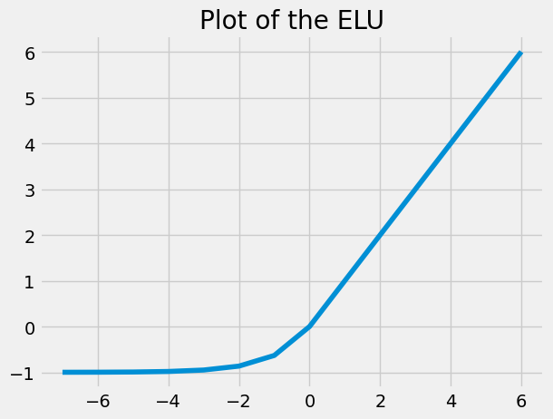

```python
from matplotlib import pyplot as plt
import numpy as np

def elu_forward(x):
    alpha = 1
    return (x >= 0.0) * x + (x < 0.0) * (np.exp(x) - 1.0)*alpha


x = np.arange(-7,7)
y = elu_forward(x)

plt.style.use('fivethirtyeight')
fig, ax = plt.subplots()
ax.plot(x, y)
ax.set_title("Plot of the ELU")
plt.show()
```

the plot of elu is above

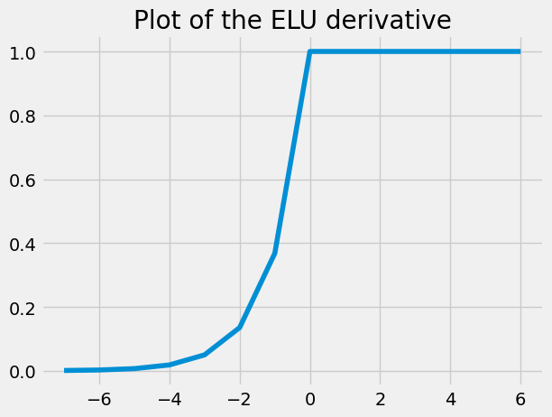

```python
from matplotlib import pyplot as plt
import numpy as np

def elu_forward_derivative(x):
    alpha = 1
    return (x >= 0.0) * 1 + (x < 0.0) * (np.exp(x) )*alpha


x = np.arange(-7,7)
y = elu_forward_derivative(x)

plt.style.use('fivethirtyeight')
fig, ax = plt.subplots()
ax.plot(x, y)
ax.set_title("Plot of the ELU derivative")
plt.show()
```

the above is the plot of derivative of elu

(b) the Swish activation function Swish is defined as x · σ(βx), where σ(z) = (1 + exp(−z))^−1 is the sigmoid function and β is either a constant or a trainable parameter.

research paper : "Searching for Activation Functions" by Prajit Ramachandran, Barret Zoph, and Quoc V. Le, which was published in 2018.

Summary of the author's motivation: The authors were motivated to explore new activation functions because traditional ones like ReLU can suffer from the "dying ReLU" problem, where neurons can get stuck during training and stop learning. They aimed to find an activation function that performs well in various architectures and tasks, avoiding the vanishing gradient problem and providing better learning characteristics.

Brief summary of the advantages of Swish activation function: The Swish activation function offers several advantages. It has a non-monotonic nature, which allows it to learn complex functions effectively. It provides smoothness compared to ReLU, reducing the risk of neuron saturation and the vanishing gradient problem. Furthermore, the Swish function is computationally efficient, making it suitable for large-scale deep learning models. Empirical results have shown that Swish can outperform ReLU and other activation functions in certain scenarios, leading to improved convergence and higher accuracy in neural networks.

the second one: Another popular activation function is the "Leaky ReLU" (LReLU) function.it is a type of activation function based on a ReLU, but it has a small slope for negative values instead of a flat slope. The slope coefficient is determined before training, i.e. it is not learnt during training.

research paper: "Rectifier Nonlinearities Improve Neural Network Acoustic Models" by Andrew L. Maas, Awni Y. Hannun, and Andrew Y. Ng, which was published in 2013.

Summary of the author's motivation: The authors aimed to address the limitations of the traditional ReLU activation function, which can lead to dead neurons during training (when the output is always negative). Dead neurons stop learning and can hinder the overall performance of deep neural networks. The motivation behind Leaky ReLU was to introduce a small, non-zero gradient for negative inputs, allowing neurons to overcome the dying ReLU problem and continue learning.

Brief summary of the advantages of Leaky ReLU activation function: Leaky ReLU overcomes the issue of dead neurons that can occur in standard ReLU. By introducing a small negative slope for negative inputs, Leaky ReLU prevents neurons from getting stuck and enables the flow of gradients during backpropagation. This property makes Leaky ReLU more robust and less likely to suffer from the vanishing gradient problem. Additionally, Leaky ReLU retains the computational efficiency of ReLU, making it a popular choice in various deep learning architectures. It has been empirically shown to improve the performance and convergence of neural networks, especially in scenarios where traditional ReLU struggles.

### Question 1.2: Feed-forward neural networks

Assume that we feed a data point $x$ with a ground-truth label $y=3$ *(with index starting from 1 as in the lecture)* to the feed-forward neural network with the ReLU activation function at hidden layers as shown in the following figure:

[figure not shown]

**(a)** What is the numerical value of the latent presentation $h^1(x)$

[1 point]

**(b)** What is the numerical value of the latent presentation $h^2(x)$?

[1 point]

**(c)** What is the numerical value of the logit $h^3(x)$?

[1 point]

**(d)** What is the corresonding prediction probabilities $p(x)$?

[1 point]

**(e)** What is the predicted class? Is it a correct or incorrect prediction?

[1 point]

**(f)** What is the cross-entropy loss value caused by the feed-forward neural network at $(x,y)$?

[1 point]

**(g)** Assume that we are applying the label smoothing technique (i.e., [link for main paper](https://papers.nips.cc/paper/2019/file/f1748d6b0fd9d439f71450117eba2725-Paper.pdf) from Goeff Hinton) with $\alpha = 0.1$. What is the relevant loss value caused by the feed-forward neural network at $(x,y)$?

[2 point]

**You need to show both formulas and numerical results for earning full mark. Although it is optional, it is great if you show your numpy code for your computation.**

*# WRITE YOUR ANSWER HERE*

```python
import tensorflow as tf
import numpy as np
# Create a tensor with a numpy array
x = np.array([[1.], [-1.], [0.]]) # dtype is float64

x = tf.constant(x) # dtype is float64
print(x)

W1 = np.array([[1.,-1.,1.],[1.,-1.,-1.],[2.,-1.,2.],[-1.,-2.,1.]])
W1 = tf.constant(W1)
print(W1)

b1 = np.array([[1.],[0.],[1.],[0.]])
b1 = tf.constant(b1)

h1 = tf.matmul(W1,x)
print(h1)
h1 = tf.add(h1,b1)
print(h1)
h1 = tf.nn.relu(h1)
print(h1)
```

```
tf.Tensor(
[[ 1.]
 [-1.]
 [ 0.]], shape=(3, 1), dtype=float64)
tf.Tensor(
[[ 1. -1.  1.]
 [ 1. -1. -1.]
 [ 2. -1.  2.]
 [-1. -2.  1.]], shape=(4, 3), dtype=float64)
tf.Tensor(
[[2.]
 [2.]
 [3.]
 [1.]], shape=(4, 1), dtype=float64)
tf.Tensor(
[[3.]
 [2.]
 [4.]
 [1.]], shape=(4, 1), dtype=float64)
tf.Tensor(
[[3.]
 [2.]
 [4.]
 [1.]], shape=(4, 1), dtype=float64)
```

(a)numberical value of the latent presentation h1(x) is [[3],[2],[4],[1]]

```python
W2 = np.array([[1.,-1.,-1.,2.],[1.,-1.,1.,-1.],[1.,2.,-1.,2.]])
W2 = tf.constant(W2)
print(W2.dtype)

b2 = tf.constant([[-1.],[1.],[0.]], dtype=tf.float64)


h2 = tf.nn.relu(tf.add(tf.matmul(W2,h1),b2))
print(h2)
```

```
<dtype: 'float64'>
tf.Tensor(
[[0.]
 [5.]
 [5.]], shape=(3, 1), dtype=float64)
```

(b) numberical value of the latent presentation h2(x) is [[0],[5],[5]]

```python
W3 = tf.constant([[1,-2,1],[1,2,-1],[-1,1,-1]], dtype=tf.float64)


b3 = tf.constant([[4],[-2],[2]], dtype=tf.float64)


h3 = tf.nn.relu(tf.add(tf.matmul(W3,h2),b3))
print(h3)
```

```
tf.Tensor(
[[0.]
 [3.]
 [2.]], shape=(3, 1), dtype=float64)
```

(c) numberical value of the latent presentation h3(x) is [[0],[3],[2]]

```python
p = tf.nn.softmax(tf.transpose(h3))
print(p)
```

```
tf.Tensor([[0.03511903 0.70538451 0.25949646]], shape=(1, 3), dtype=float64)
```

(d) the prediction p(x) is [0.03511903 0.70538451 0.25949646]

(e) the prediction class is 2 as the second class is the biggest. the prediction is not right, as the ground truth is class 3

```python
y_true = tf.constant([[0.],[0.],[1.]])
#print(tf.transpose(y_true))

y_true = tf.transpose(y_true)
print(y_true.shape)
print(y_true.dtype)
print(p.shape)
cce = tf.keras.losses.CategoricalCrossentropy()
loss = cce(y_true, p).numpy()
print(loss)
```

```
(1, 3)
<dtype: 'float32'>
(1, 3)
1.3490122167681864
```

(f) the cross-entropy loss value caused by the feed-forward neural network is 1.3490122167681864

```python
K = 3
alpha = 0.1
y_true = y_true*tf.constant(1.-alpha,dtype=tf.float32)+(alpha/K)
print(y_true)
cce2 = tf.keras.losses.CategoricalCrossentropy()
loss = cce2(y_true, p).numpy()
print(loss)
```

[output not shown]

### Question 1.3: Back propagation

Assume that we are constructing a multilayered feed-forward neural network for a classification problem with three classes where the model parameters will be generated randomly using your student ID.

The architecture is as follows: $3 (Input)\rightarrow4(LeakyReLU)\rightarrow 3(Output)$ (see figure below). Also note that the model parameters are randomly generated.

[figure not shown]

We then feed a feature vector $x=\left[\begin{array}{ccc} 1 & -1 & 0\end{array}\right]^{T}$ with ground-truth label $y=3$ to the above network.

**You need to show both formulas, numerical results, and your numpy code for your computation for earning full marks.**

**(a)** Suppose that we use the cross-entropy (CE) loss. What is the value of the CE loss $l$?

[2 point]

**(b)** What are the derivatives $\frac{\partial l}{\partial h^{2}},\frac{\partial l}{\partial W^{2}}$, and $\frac{\partial l}{\partial b^{2}}$

[3 points]

**(c)** What are the derivatives $\frac{\partial l}{\partial h^{1}}, \frac{\partial l}{\partial \bar{h}^{1}},\frac{\partial l}{\partial W^{1}}$, and $\frac{\partial l}{\partial b^{1}}$?

[3 points]

**(d)** Assume that we use SGD with learning rate $\eta=0.01$ to update the model parameters. What are the values of $W^2, b^2$ and $W^1, b^1$ after updating?

[2 points]

```python
import numpy as np

# 1. Randomly generate model parameters based on the student ID
np.random.seed(32950683)
W1 = np.random.randn(4, 3)
b1 = np.random.randn(4, 1)
W2 = np.random.randn(3, 4)
b2 = np.random.randn(3, 1)

# 2. Activation functions and their derivatives
def leaky_relu(z, alpha=0.01):
      return np.where(z>0,z,alpha*z)
```

```python
def leaky_relu_derivative(z, alpha=0.01):
    return np.where(z > 0, 1, alpha)

def softmax(z):
    return np.exp(z)/sum(np.exp(z))
```

```python
def cross_entropy(predictions, targets):
    log_preds = np.log(predictions)
    return -np.sum(targets * log_preds)

# 3. Forward pass
x = np.array([[1], [-1], [0]])
y = np.array([[0], [0], [1]])

h1bar = np.dot(W1, x) + b1
h1 = leaky_relu(h1bar)
h2 = np.dot(W2, h1) + b2
p = softmax(h2)
loss = cross_entropy(p, y)

print(loss)
```

```
0.6067788379946293
```

(a) the loss value is 0.607

```python
dL_h2 = np.array([[0], [0], [p[2].item()-1]])
print(dL_h2)
dL_W2=np.dot(dL_h2,h1.T)
print(dL_W2)
dL_b2 =dL_h2

dL_h1=np.dot(W2.T,dL_h2)
print(dL_h1)
dh1_h1bar = np.array([[0.01],[0.01],[0.01],[0.01]])
dL_h1bar=dL_h1*dh1_h1bar
print(dL_h1bar)
dL_W1=np.dot(dL_h1bar,x.T)
print(dL_W1)
dL_b1=dL_h1bar
```

```
[[ 0.        ]
 [ 0.        ]
 [-0.45489609]]
[[ 0.00000000e+00  0.00000000e+00  0.00000000e+00  0.00000000e+00]
 [ 0.00000000e+00  0.00000000e+00  0.00000000e+00  0.00000000e+00]
 [ 9.15555001e-04 -5.89077715e-02 -1.01824534e-01  6.77918362e-05]]
[[-0.2330628 ]
 [-0.2691863 ]
 [-0.22167556]
 [-0.12953759]]
[[-0.00233063]
 [-0.00269186]
 [-0.00221676]
 [-0.00129538]]
[[-0.00233063  0.00233063  0.        ]
 [-0.00269186  0.00269186  0.        ]
 [-0.00221676  0.00221676  0.        ]
 [-0.00129538  0.00129538  0.        ]]
```

(b) **The detailed hand written process image "A1_Q3_part1" and "A1_Q3_part2" can be found in the folder**

the derivative of loss w.r.t. h2:

[[ 0. ]

[ 0. ]

[-0.45489609]]

the derivative of loss w.r.t. W2:

[[ 0.00000000e+00 0.00000000e+00 0.00000000e+00 0.00000000e+00]

[ 0.00000000e+00 0.00000000e+00 0.00000000e+00 0.00000000e+00]

[ 9.15555001e-04 -5.89077715e-02 -1.01824534e-01 6.77918362e-05]]

the derivative of loss w.r.t. b2:

[[ 0. ]

[ 0. ]

[-0.45489609]]

the derivative of loss w.r.t. h1:

[[-0.2330628 ]

[-0.2691863 ]

[-0.22167556]

[-0.12953759]]

the derivative of loss w.r.t. h1bar:

[[-0.00233063]

[-0.00269186]

[-0.00221676]

[-0.00129538]]

the derivative of loss w.r.t. W1:

[[-0.00233063 0.00233063 0. ]

[-0.00269186 0.00269186 0. ]

[-0.00221676 0.00221676 0. ]

[-0.00129538 0.00129538 0. ]]

the derivative of loss w.r.t. b1:

[[-0.00233063]

[-0.00269186]

[-0.00221676]

[-0.00129538]]

```python
lr =0.01
W1 = W1 - lr*dL_W1
print(W1)
```

```
[[-1.16740745 -0.05751646  1.04571584]
 [ 0.63426379  0.97862846  1.15888219]
 [-1.10596783 -0.84039029 -0.09024082]
 [-0.17274716  0.24087738  0.81365638]]
```

the updated W1 :

[[-1.16740745 -0.05751646 1.04571584]

[ 0.63426379 0.97862846 1.15888219]

[-1.10596783 -0.84039029 -0.09024082]

[-0.17274716 0.24087738 0.81365638]]

```python
b1 = b1 - lr*dL_b1
print(b1)
```

```
[[0.90869407]
 [0.47394263]
 [0.48948534]
 [0.39876069]]
```

the updated b1:

[[0.90869407]

[0.47394263]

[0.48948534]

[0.39876069]]

```python
W2 = W2 - lr*dL_W2
print(W2)
```

```
[[-1.43092671 -0.19827734  0.49154411 -0.43657713]
 [-0.70905934 -1.52716864  1.01093921 -1.14976328]
 [ 0.51233378  0.59234247  0.48832856  0.28476235]]
```

the updated W2:

[[-1.43092671 -0.19827734 0.49154411 -0.43657713]

[-0.70905934 -1.52716864 1.01093921 -1.14976328]

[ 0.51233378 0.59234247 0.48832856 0.28476235]]

```python
b2 = b2 - lr*dL_b2
print(b2)
```

```
[[0.93754939]
 [0.01518437]
 [1.34447163]]
```

The updated b2:

[[0.93754939]

[0.01518437]

[1.34447163]]

### Question 1.4: Optimization with gradient descent

In this question, we will take a step further to get deeper understanding about gradient descent, one of the most important optimization techniques in deep learning.

**(a)** Write the pseudo-code to implement the gradient descent algorithm and explain in your words what each line of the code does.

[2 point]

**(b)** Explain in your own words why the negative gradient direction is the direction that give us a fastest decrease of loss value.

[2 points]

(a)

1. initialize parameters for all weights, biases in the network
2. set a learning rate

3.repeat until results converge: a.compute the gradient of loss with respect to all parameters using backpropagation

b.update parameters: parameter = parameter - learning_rate* gradient_of_parameter

4.return the optimized parameter

Explanation: 1 initialize all parameters of the model, pick a start point

2.choose the learning rate, it should not be too big, or too small. picking the right learning rate highly depends on experience

3.update the parameters based on the loss gradient w.r.t each parameter, the direction is opposite

4.after the results converges, the resultant parameters are the trained parameter we get

(b) intuitively, the gradient direction of a function is the direction of steepest increase of the function. The opposite direction would be the steepest decrease of the function.

Imagining you are climbing a mountain, the opposite direction of the steepest increase would be the steepest decrease as long as the surface of the mountain is differentiable at your location

mathmatical prove: we call "gradient" the gradient vector at the point x.

u is another unit vector at x

the rate of change along u is: dot product of gradient and u = |gradient|*|u|*cos(theta),

u is a unit vector, so |u|=1,

so it becomes |gradient|*cos(theta), the result becomes smallest when theta is 180 degree, which is the opposite direction as long as the function is differentiable at this point x.